# The barrier option pricing

Vitalii Rudko

June, 2020

# 1 Description

Hull (2015) defines a barrier option as an option which payoff depends on whether the underlying asset hit the certain price level during the specified time range. In general, there are two main classes of barriers options, knock-out options and knock-in options. The knock-out options cease to exist after reaching a particular price level, knock-in options work the other way around, they commence to exist after hitting the barrier. The barrier options are usually traded on the OTC market. The additional price limits make them less riskier, than plain vanilla options, which in turn reduces their price.

In this project, the down-and-in call and the down-and-in put option will be considered. Down-and-in is a type of the knock-in option, when the barrier is set below the initial price. In order to describe its payoff function, we should define the minimum of time series of the spot prices. Let $S=\left\{S_{t}: 0<t<T\right\}$ be a spot price process and $m_{S}=\inf \left\{S_{t} : 0<t<T\right\}$ be an infinium of the set $S$, then the payoff function at the maturity for call is,

$$\begin{equation}
\pi\left(S_{T}, m_{S}\right)=\max(S_{T}-K, 0)\mathbf{1}^{+}\left(m_{S} \leq H\right)
\end{equation}$$

and for put,

$$\begin{equation}
\pi\left(S_{T}, m_{S}\right)=\max(K-S_{t}, 0)\mathbf{1}^{+}\left(m_{S} \leq H\right)
\end{equation}$$

where $K$ is a strike price, $H$ is a price limit and $\mathbf{1}^{+}\left(m_{S} \leq H\right)$ is an indicator functions, which takes $1$ if $m_{S} \leq H$, and $0$ otherwise.

Finally, the pricing model can be introduced. The classical method is based on Black-Scholes-Merton model. So, according to Hull (2015) the price of the down-and-in call is,

$$\begin{equation}
c =S_{0} e^{-q T}\left(H / S_{0}\right)^{2 \lambda} N(y)-K e^{-r T}\left(H / S_{0}\right)^{2 \lambda-2} N(y-\sigma \sqrt{T})
\end{equation}$$

where,
$$\begin{equation}
\lambda=\frac{r-q+\sigma^{2} / 2}{\sigma^{2}}
\end{equation}$$

$$\begin{equation}
y=\frac{\ln \left[H^{2} /\left(S_{0} K\right)\right]}{\sigma \sqrt{T}}+\lambda \sigma \sqrt{T}
\end{equation}$$

and the price of the down-and-in put is,
$$\begin{align}
p =-S_{0} N\left(-x_{1}\right) e^{-q T}+K e^{-r T} N(&\left.-x_{1}+\sigma \sqrt{T}\right)+S_{0} e^{-q T}\left(H / S_{0}\right)^{2 \lambda}\left[N(y)-N\left(y_{1}\right)\right] \\
-& K e^{-r T}\left(H / S_{0}\right)^{2 \lambda-2}\left[N(y-\sigma \sqrt{T})-N\left(y_{1}-\sigma \sqrt{T}\right)\right]
\end{align}$$
where
$$\begin{equation}
x_{1}=\frac{\ln \left(S_{0} / H\right)}{\sigma \sqrt{T}}+\lambda \sigma \sqrt{T}
\end{equation}$$

$$\begin{equation}
y_{1}=\frac{\ln \left(H / S_{0}\right)}{\sigma \sqrt{T}}+\lambda \sigma \sqrt{T}
\end{equation}$$

The function $N(x)$ is the cumulative probability distribution function, where $x$ has a standard normal distribution. Also, $r$ is the continuously compounded risk-free rate, $q$ is the dividend yield, $\sigma$ is the stock price volatility, and $T$ is the time to maturity.

## 1.1 Assumptions

The list of assumptions for our options is listed bellow.

1. The current price, $S_0 = \$50$
2. The strike price, $K = \$48$
3. The price limit, $H = \$47$
4. The stock price volatility, $\sigma = 30\%$
5. The risk-free rate, $r = 5\%$ per annum
6. The time to expiration, $T = 0.5$ years
7. The dividend yield, $q = 0\%$.

# 2 Payoff function

If during the lifetime the spot prices reached the barrier the the payoff is the same as for plain vanilla call option, see Figure 2.1, otherwise the option will expire worthless.

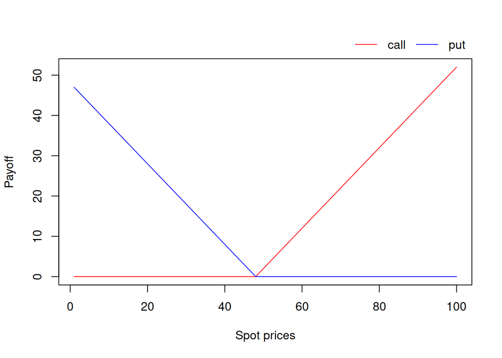

Figure 2.1: Payoff function given the option was activated.

It would be helpful to show how the option behaves in time. For this purpose we are defining the payoff function in R for down-and-in call first.

```r
#Defining payoff function.
payoff <- function(x, K, H){
  output <- c()
  C <- 0
  n <- length(x)

  for(i in 1:n){
    C <- C + 1
    if(x[i] <= H) break
  }

  for(i in C:n){
    output <- append(output, max(x[i] - K, 0))
  }

  zero <- c(rep(0,C-1))

  return(c(zero,output))
}
```

The example is presented in Figure 2.2. As we see, the function is inactive until price hit the barrier.

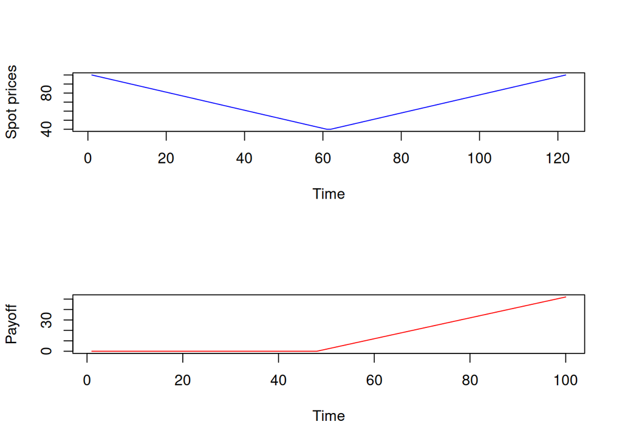

Figure 2.2: Payoff function of down-and-in call for time series.

For down-and-in put, the function is almost similar. The example of its output is shown in Figure 2.3.

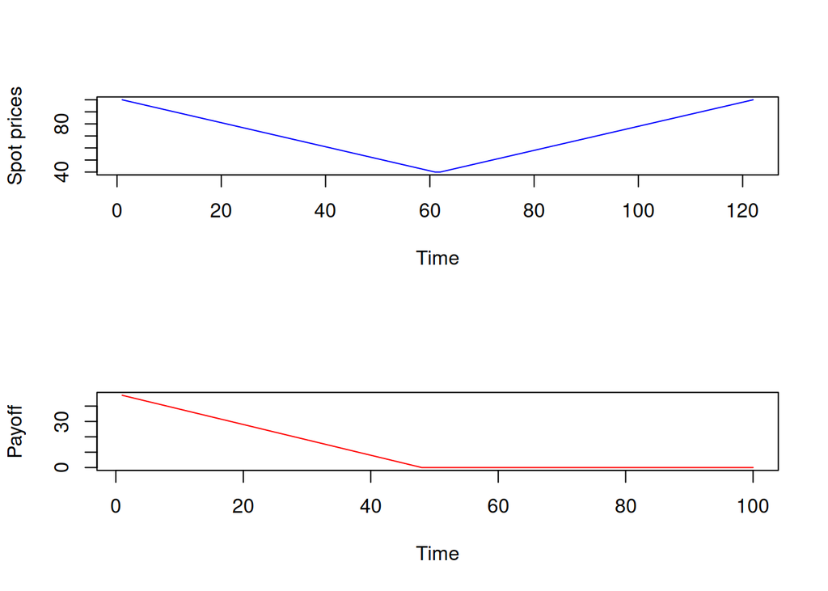

Figure 2.3: Payoff function of down-and-in put for time series.

# 3 Pricing

The pricing formula for down-and-in call is defined in R in the following way.

```r
#Defining pricing function for call.
BSMcall <- function(S0, K, H, sigma, r, t, q){
  lambda <- (r-q+sigma^2/2)/sigma^2
  y <- log(H^2/(S0*K)) / sigma*sqrt(t) + lambda*sigma*sqrt(t)

  lhs <- S0*exp(-q*t)*(H/S0)^(2*lambda)*pnorm(y)
  rhs <- -K*exp(-r*t)*(H/S0)^(2*lambda-2)*pnorm(y-sigma*sqrt(t))
  price <-  lhs + rhs

  if(price < 0) return(0)
  else return(price)
}
```

Therefore the price of the option based on our assumptions is,

```
## [1] 2.577483
```

Similarly, we define the price function for down-and-in put.

```r
#Defining pricing function for put.
BSMput<- function(S0, K, H, sigma, r, t, q){
  lambda <- (r-q+sigma^2/2)/sigma^2
  y <- log(H^2/(S0*K)) / sigma*sqrt(t) + lambda*sigma*sqrt(t)

  x1 <- log(S0/H)/sigma*sqrt(t) + lambda*sigma*sqrt(t)
  y1 <- log(H/S0)/sigma*sqrt(t) + lambda*sigma*sqrt(t)

  part1 <- -S0*pnorm(-x1)*exp(-q*t) + K*exp(-r*t)*pnorm(-x1 + sigma*sqrt(t))
  part2 <- S0*exp(-q*t)*(H/S0)^(2*lambda)*(pnorm(y) - pnorm(y1))
  part3 <- -K*exp(-r*t)*(H/S0)^(2*lambda-2)*(pnorm(y - sigma*sqrt(t)) - pnorm(y1 - sigma*sqrt(t)))

    price <- part1 + part2 + part3
  if(price < 0) return(0)
  else return(price)
}
```

The price of the put then equals to,

```
## [1] 2.728114
```

# 4 Sensitivity analysis of the down-and-in call

The last stage is Sensitivity analysis of the option. We are analyzing it by changing every argument, ceteris paribus, in our pricing function. As we see in Figure 4.1 as spot price increases, the option price decreases, because the probability the option hit the barrier is falling as well.

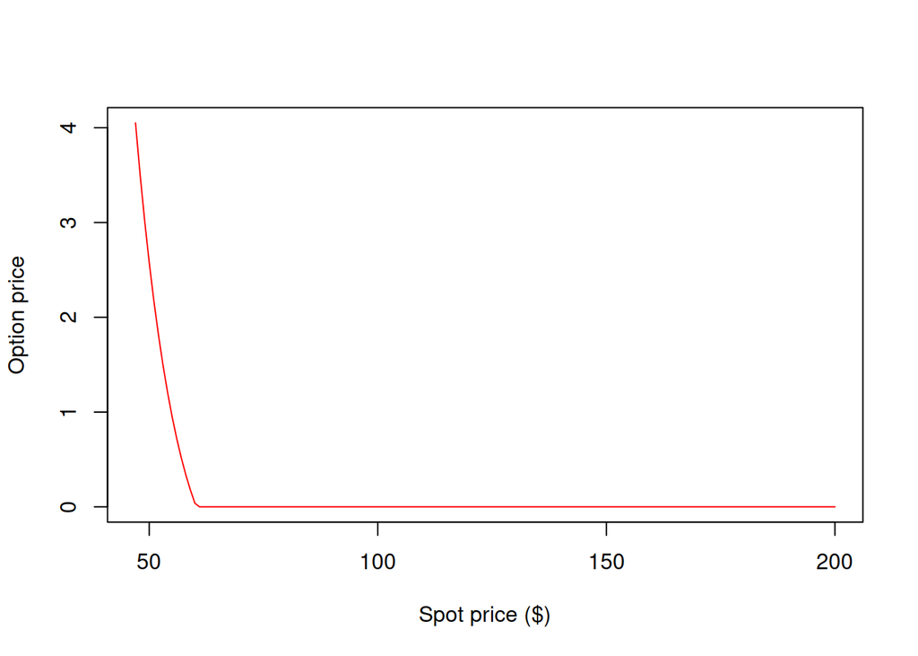

Figure 4.1: Sensitivity analysis in terms of spot prices.

The same situation is observer in Figure 4.2. The probability, that the option will be both exercised and activated increases as barrier is getting closer to the strike price.

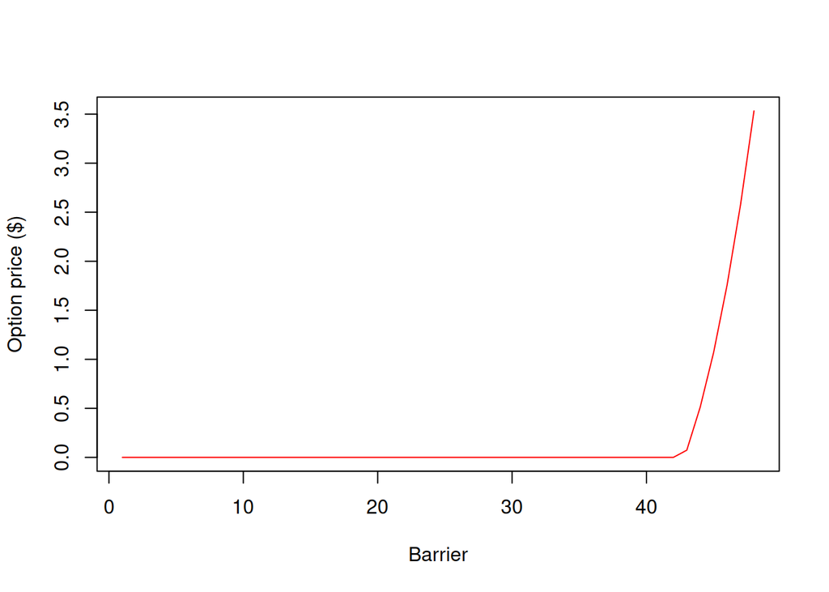

Figure 4.2: Sensitivity analysis in terms of barriers.

As we see in Figure 4.3, the price of the option is also positively affected by the rise of the interest rate, as it behaves as a plain vanilla call option after the activation.

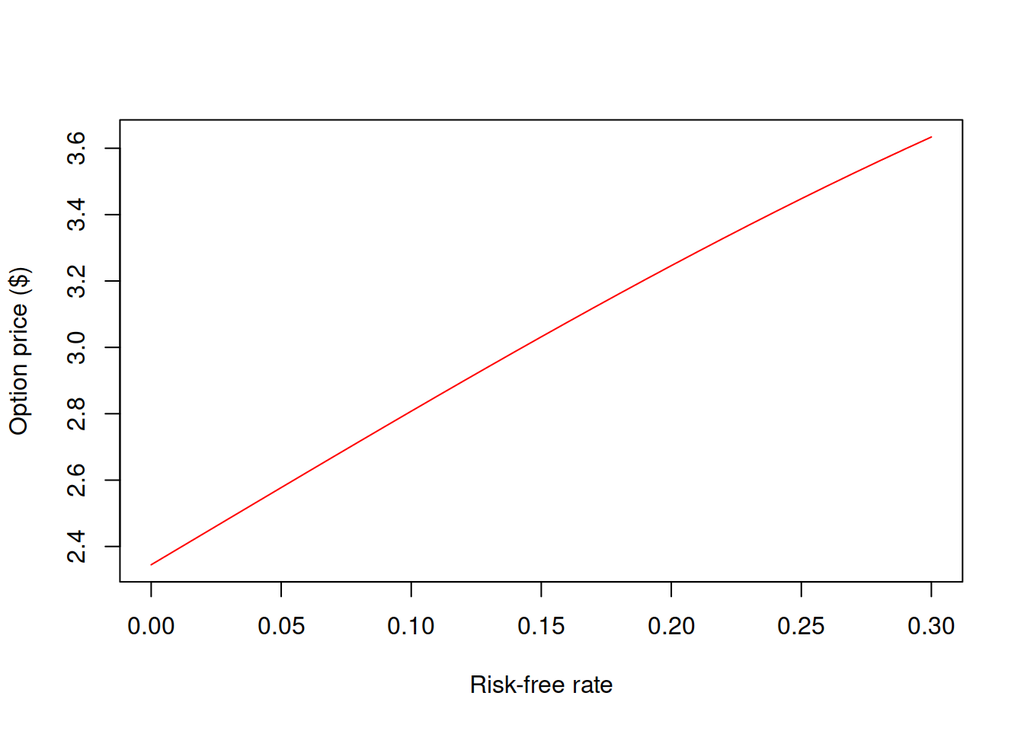

Figure 4.3: Sensitivity analysis in terms of risk-free rate.

Figure 4.4 shows the obvious positive relation between the price of the option and the volatility of the underlying stock.

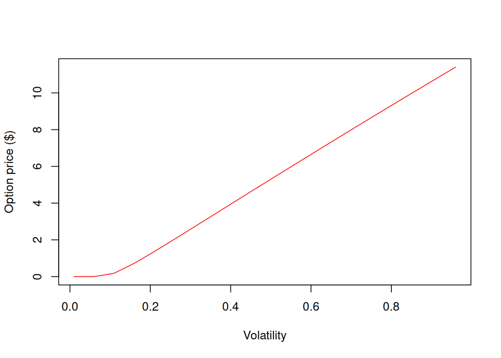

Figure 4.4: Sensitivity analysis in terms of volatility.

As we increase time to maturity, we also add more uncertainty, thus the price must be higher, see Figure 4.5.

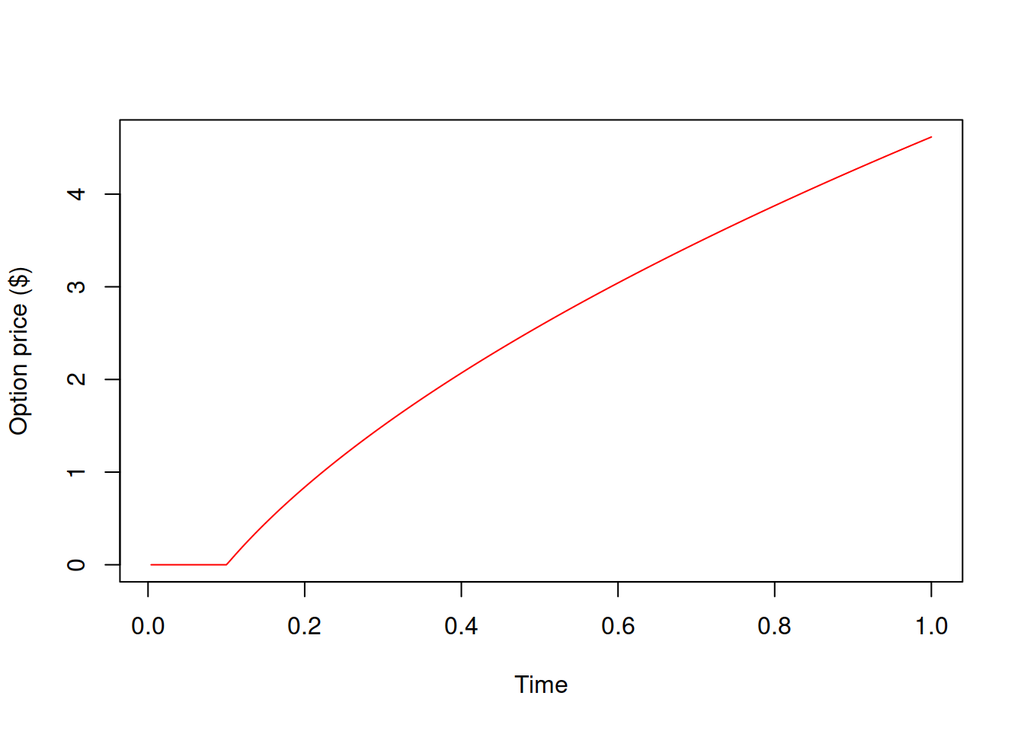

Figure 4.5: Sensitivity analysis in terms of time.

The higher the dividend yield the bigger the drop of the stock after ex-dividend day will be. The relation between the yield and the option price is presented in Figure 4.6.

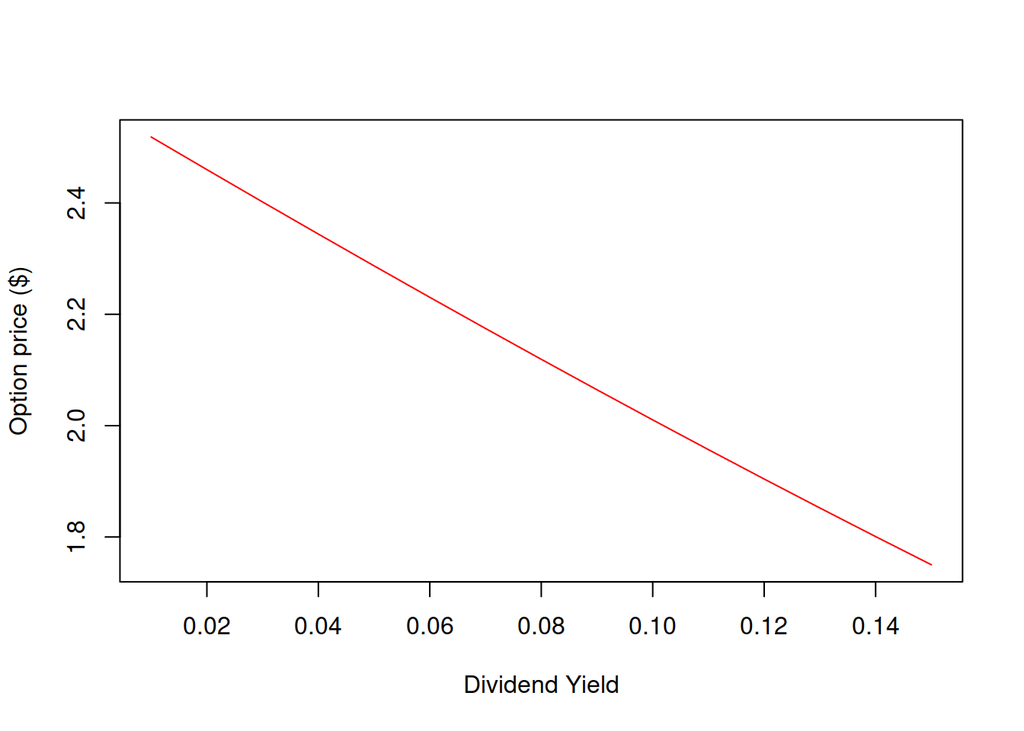

Figure 4.6: Sensitivity analysis in terms of dividend yield.

# 5 Sensitivity analysis of the down-and-in put

This section is devoted to sensitivity analysis of down-and-in put option. In the first Figure 5.1 we observe, that the spot prices influence down-and-in put in identical way we have seen in case of down-and-in call.

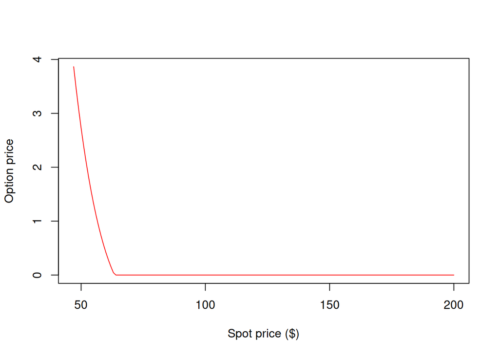

Figure 5.1: Sensitivity analysis in terms of spot prices.

The analysis of barrier parameter shows an interesting pattern, the price of the put option starts to fall after some point, when it gets closer to the strike price, see Figure 5.2. When $H > K$, then the down-and-in put becomes a simple put option, as at the start it has already been activated. It also means the option is out of the money, thus must be cheaper.

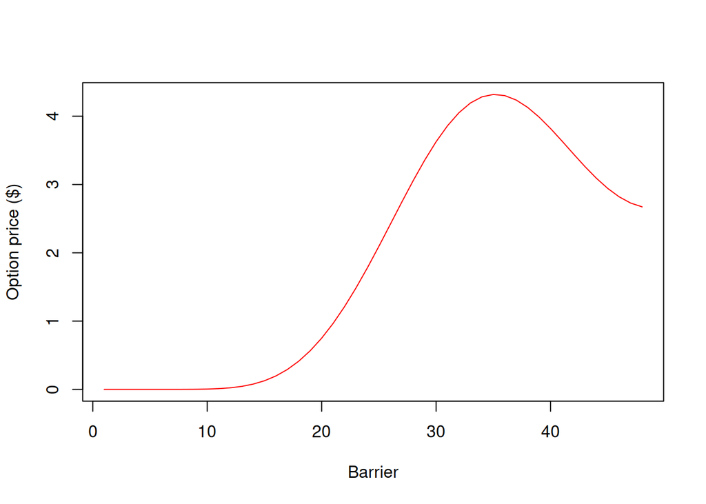

Figure 5.2: Sensitivity analysis in terms of barriers.

In Figure 5.3 we see the predictable behavior, as the interest rates rise the discount factor devour all the gains.

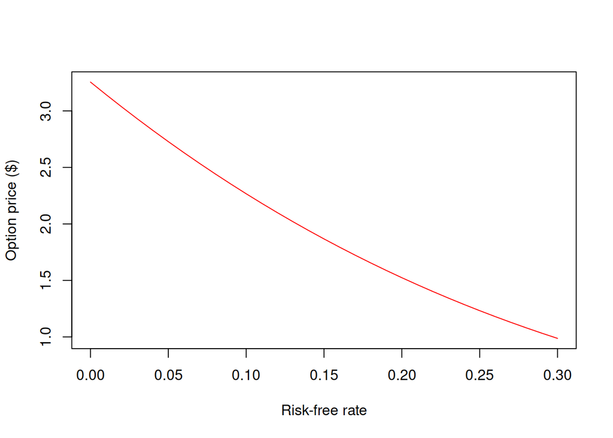

Figure 5.3: Sensitivity analysis in terms of risk-free rate.

Figure 5.4 once again confirms the fact, that the large volatility is always good for the price of an option.

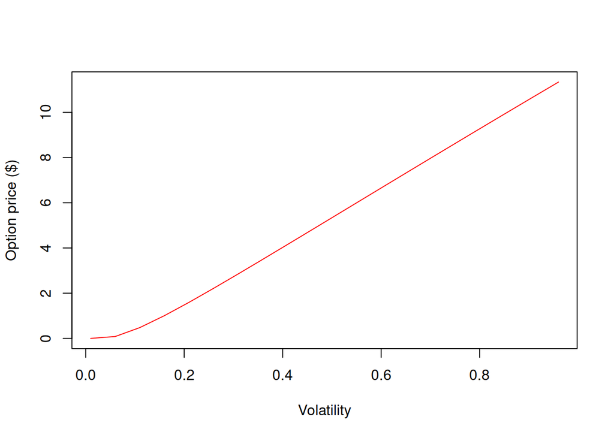

Figure 5.4: Sensitivity analysis in terms of volatility.

As was discussed previously the time has a positive impact on the call option price, it also applies to the put option.

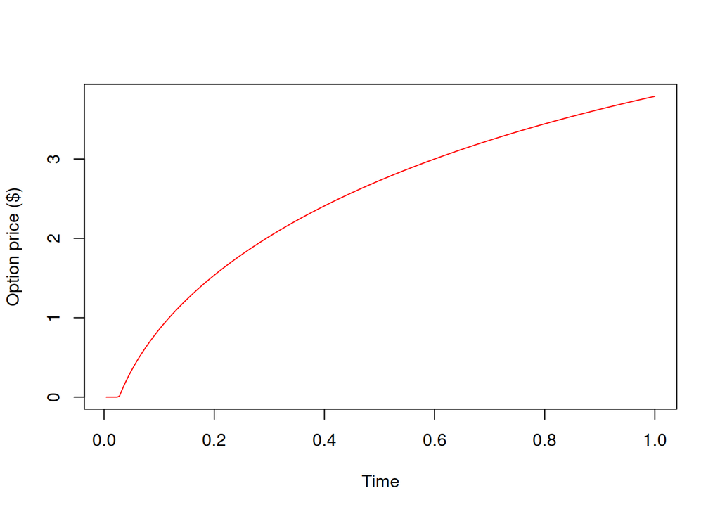

Figure 5.5: Sensitivity analysis in terms of time.

The higher the dividend yield, the higher the price of the put option, since the seller must be more compensated for selling rights to that dividend.

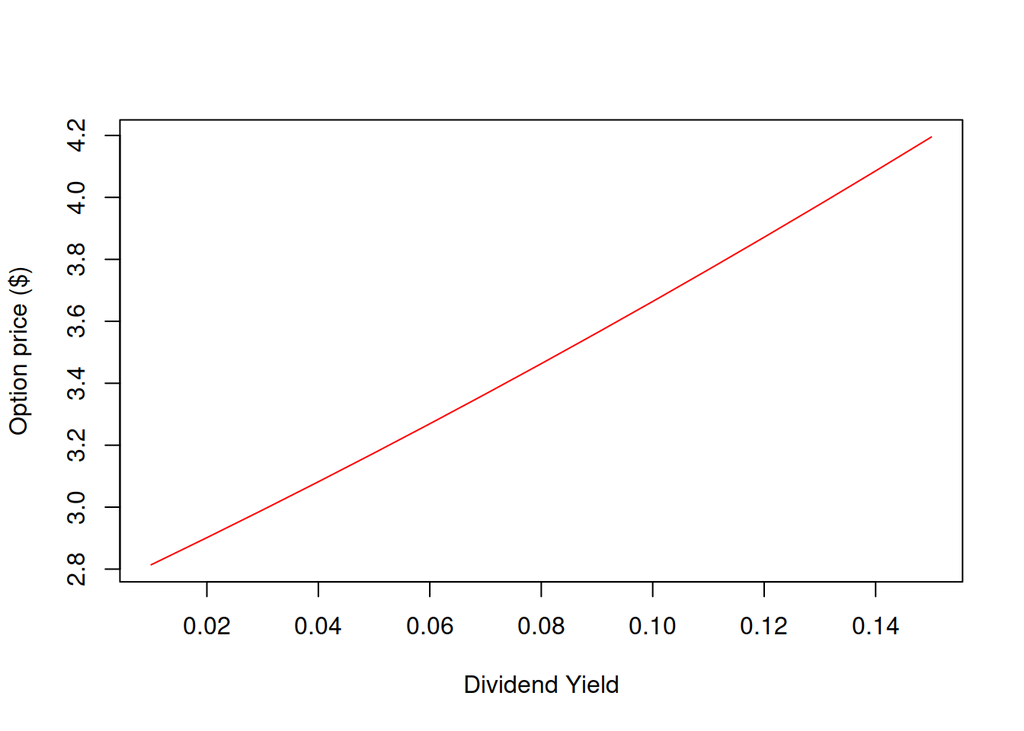

Figure 5.6: Sensitivity analysis in terms of dividend yield.

# References

Hull, John. 2015. *Options, Futures, and Other Derivatives*. Ninth edition. Boston: Pearson.

Westermark, Niklas. 2009. “Barrier Option Pricing Degree Project in Mathematics , First Level.” In.